# 計量経済学応用

マッチング

矢内 勇生

2018-05-30（改訂: 2019-05-26）

# 準備

今回使うパッケージを読み込む。MatchIt と Zelig は初めて使うので、必要ならまずインストールする。

```r
#install.packages(c("MatchIt", "Zelig"), dependencies = TRUE)
library("tidyverse")
library("broom")
library("MatchIt")
library("Zelig")
```

次に、教科書の[サポートページ](http://www.yuhikaku.co.jp/static/studia_ws/index.html) から[データのzipファイル](http://contents.yuhikaku.co.jp/nibu/econome_1st/data.zip) をダウンロードして展開し、10_1_income.csv をプロジェクト内の data フォルダに保存する。

保存できたら、データを読み込む。

```r
INC <- read_csv("data/10_1_income.csv")
```

データの中身を確認する。

```r
glimpse(INC)
```

```
## Observations: 4,371
## Variables: 6
## $ cograd   <dbl> 0, 0, 0, 0, 0, 0, 0, 0, 0, 0, 0, 0, 0, 0, 0, 0, 0, 0, 0…
## $ female   <dbl> 0, 0, 0, 1, 1, 1, 1, 1, 1, 1, 1, 1, 1, 1, 1, 1, 0, 0, 1…
## $ married  <dbl> 0, 0, 0, 0, 0, 0, 1, 1, 1, 1, 1, 1, 1, 1, 1, 1, 0, 0, 0…
## $ pacograd <dbl> 0, 0, 0, 0, 0, 0, 0, 0, 0, 0, 0, 0, 0, 0, 0, 0, 0, 0, 0…
## $ sibs     <dbl> 0, 0, 0, 0, 0, 0, 0, 0, 0, 0, 0, 0, 0, 0, 0, 0, 0, 0, 0…
## $ lincome  <dbl> 4.605170, 5.010635, 5.298317, 5.010635, 4.605170, 5.010…
```

6つの変数が含まれていることがわかる。

# マッチング法：デザイン

教科書のデータを使い、大学教育（大学を卒業したかどうか、cograd）が所得（対数所得、lincome）に与える影響を推定する場合を考えよう。大学を卒業したかどうかはランダムに割当てられていないと考えられるので、観察された4つの共変量 (female, married, pacogra, sibs) でマッチングを行う。

Rでマッチング法を使うためのパッケージ、関数はいくつかあるが、今回は **MatchIt** パッケージを使う。

## 正確マッチング (Exact Matching)

まず、処置群（大学を卒業した人たい）の各個体に対し、統制群（大学を卒業していない人たち）の中から共変量の値が完全に同じものを見つけてマッチングしよう。`matchit()` 関数を使い、次のように書く。method（方法）には、**exact（正確に）**を指定する。

```r
m_exact <- matchit(cograd ~ female + married + pacograd + sibs,
                   data = INC, method = "exact")
summary(m_exact)
```

```
##
## Call:
## matchit(formula = cograd ~ female + married + pacograd + sibs,
##     data = INC, method = "exact")
##
## Sample sizes:
##           Control Treated
## All          3003    1368
## Matched      2979    1366
## Discarded      24       2
##
## Matched sample sizes by subclass:
##    Treated Control Total
## 1       17      39    56
## 2       12      38    50
```

[output cut: 37 more lines]

マッチングの結果、処置群 (Treated) の1,366の個体に対して、統制群 (Control) の2,979の個体がマッチングされたことがわかる。また、処置群から2個体、統制群から24個体が、マッチング相手が見つからなかったために捨てられている。

## 区間マッチング (subcalassification)

次に、区間マッチング (subclassificaiton) を行ってみよう。先ほどと同じ関数を使うが、今回は `method = subclass` を指定する。また、subclass の数を 5 に設定する。 距離は、傾向スコア (propensity score) で測ることにする（既定値なので、何も指定しなくて良い）。

```r
m_subclass <- matchit(cograd ~ female + married + pacograd + sibs,
                   data = INC, method = "subclass", subclass = 5)
summary(m_subclass)
```

```
##
## Call:
## matchit(formula = cograd ~ female + married + pacograd + sibs,
##     data = INC, method = "subclass", subclass = 5, sub.by = "treat")
## Summary of balance for all data:
##          Means Treated Means Control Mean Diff eQQ Med eQQ Mean eQQ Max
## distance        0.3497        0.2963    0.0534  0.0441   0.0535  0.1384
## female          0.3728        0.5611   -0.1883  0.0000   0.1879  1.0000
## married         0.4525        0.4762   -0.0237  0.0000   0.0234  1.0000
## pacograd        0.4788        0.3370    0.1418  0.0000   0.1418  1.0000
## sibs            1.3392        1.4712   -0.1320  0.0000   0.1308  2.0000
##
##
## Summary of balance by subclasses:
## , , Subclass 1
##
##          Means Treated Means Control Mean Diff eQQ Med eQQ Mean eQQ Max
## distance        0.1957        0.1924    0.0033  0.0000   0.0039  0.0369
## female          0.9890        0.9875    0.0015  0.0000   0.0037  1.0000
## married         0.4228        0.5471   -0.1243  0.0000   0.1250  1.0000
## pacograd        0.0551        0.0567   -0.0016  0.0000   0.0037  1.0000
## sibs            1.5110        1.6214   -0.1103  0.0000   0.1213  1.0000
##
## , , Subclass 2
##
##          Means Treated Means Control Mean Diff eQQ Med eQQ Mean eQQ Max
## distance        0.2955        0.2962   -0.0007  0.0000   0.0009  0.0312
## female          0.3665        0.3227    0.0438  0.0000   0.0452  1.0000
## married         0.4706        0.4503    0.0203  0.0000   0.0226  1.0000
## pacograd        0.3665        0.3246    0.0419  0.0000   0.0407  1.0000
## sibs            2.0860        2.1107   -0.0247  0.0000   0.0317  2.0000
##
## , , Subclass 3
##
##          Means Treated Means Control Mean Diff eQQ Med eQQ Mean eQQ Max
## distance        0.3377        0.3343    0.0033  0.0000   0.0033  0.0336
## female          0.4826        0.5795   -0.0969  0.0000   0.0972  1.0000
## married         0.7188        0.6548    0.0639  0.0000   0.0660  1.0000
## pacograd        0.4826        0.5795   -0.0969  0.0000   0.0972  1.0000
## sibs            1.0000        1.0000    0.0000  0.0000   0.0000  0.0000
```

[output cut: 26 more lines]

```
## Summary of balance across subclasses
##          Means Treated Means Control Mean Diff eQQ Med eQQ Mean eQQ Max
## distance        0.3497        0.3467    0.0017       0   0.0035  0.0401
## female          0.3728        0.3931    0.0228       0   0.0358  0.7646
## married         0.4525        0.4376    0.0334       0   0.0658  1.0000
## pacograd        0.4788        0.4849    0.0229       0   0.0358  0.7646
## sibs            1.3392        1.3500    0.0318       0   0.0680  0.9510
##
## Percent Balance Improvement:
##          Mean Diff. eQQ Med  eQQ Mean eQQ Max
## distance    94.4712     100   93.5385 71.0519
## female      89.2441       0   80.9339 23.5380
## married     37.0964       0 -181.2500  0.0000
## pacograd    95.6717       0   74.7423 23.5380
## sibs        91.7824       0   48.0447 52.4488
```

結果を確認してみよう。まず、各サブクラスごとにそれぞれの共変量について処置群の平均値 (Means Treated) と統制群の平均値 (Means Control)、そして2つの平均値の差 (Mean Diff) が 示されている。すべての Mean Diff が0になるのが理想である。実際には、0から離れている値がないかどうか確認する。差が大きいところがあれば、バランスが悪いということであり、マッチングがうまくいかなかったと判断できる。

しかし、共変量ごとに単位が違うと、どれくらいの差まで許容できるかどうかわかりにくいので、標準化バイアス（standardized difference）を使う。`summary()` で `standardize = TRUE` を指定すればよい。

```r
(sum_m_subclass <- summary(m_subclass, standardize = TRUE))
```

```
##
## Call:
## matchit(formula = cograd ~ female + married + pacograd + sibs,
##     data = INC, method = "subclass", subclass = 5, sub.by = "treat")
## Summary of balance for all data:
##          Means Treated Means Control Std. Mean Diff. eCDF Med eCDF Mean
## distance        0.3497        0.2963          0.5023   0.1461    0.1184
## female          0.3728        0.5611         -0.3893   0.0941    0.0941
## married         0.4525        0.4762         -0.0476   0.0119    0.0119
## pacograd        0.4788        0.3370          0.2838   0.0709    0.0709
## sibs            1.3392        1.4712         -0.1763   0.0031    0.0165
##          eCDF Max
## distance   0.2164
## female     0.1883
## married    0.0237
## pacograd   0.1418
## sibs       0.0762
##
##
## Summary of balance by subclasses:
## , , Subclass 1
##
##          Means Treated Means Control Std. Mean Diff. eCDF Med eCDF Mean
## distance        0.1957        0.1924          0.0311   0.0074    0.0254
## female          0.9890        0.9875          0.0031   0.0007    0.0007
## married         0.4228        0.5471         -0.2497   0.0622    0.0622
## pacograd        0.0551        0.0567         -0.0031   0.0008    0.0008
## sibs            1.5110        1.6214         -0.1473   0.0061    0.0158
##          eCDF Max
## distance   0.1133
## female     0.0015
## married    0.1243
## pacograd   0.0016
## sibs       0.0790
##
## , , Subclass 2
##
##          Means Treated Means Control Std. Mean Diff. eCDF Med eCDF Mean
## distance        0.2955        0.2962         -0.0067   0.0108    0.0136
## female          0.3665        0.3227          0.0906   0.0219    0.0219
```

[output cut: 68 more lines]

```
## sibs            1.3392        1.3500          0.0425   0.0065    0.0131
##          eCDF Max
## distance   0.0762
## female     0.0350
## married    0.0644
## pacograd   0.0353
## sibs       0.0391
##
## Percent Balance Improvement:
##          Std. Mean Diff.  eCDF Med eCDF Mean  eCDF Max
## distance         94.4712   82.5907   74.1900   64.7853
## female           89.2441   81.4133   81.4133   81.4133
## married          37.0964 -171.4687 -171.4687 -171.4687
## pacograd         95.6717   75.1291   75.1291   75.1291
## sibs             91.7824 -108.1016   20.3643   48.7077
```

各共変量について標準化バイアス (Std. Mean Diff.) の絶対値が0.1未満になっていれば、バランスがいいと判断できる。結果を見ると、絶対値が0.1より大きいところがいくつもあるので、あまりバランスはよくないと判断できる。

バランスチェックには、図も使う。まず、標準化バイアスを図にしてみよう。

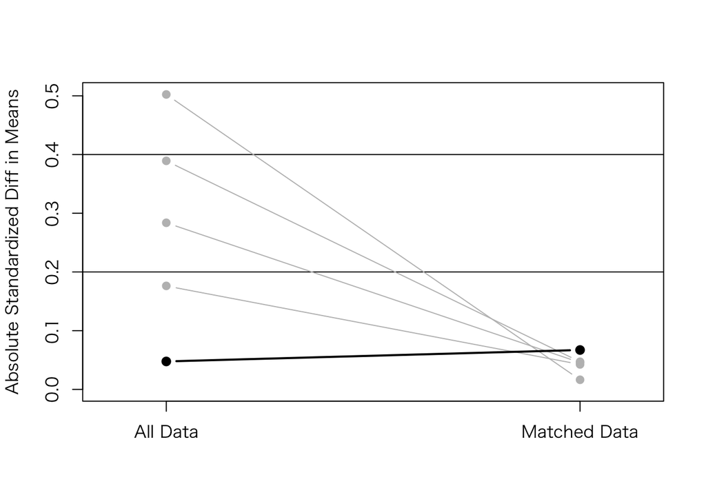

```r
plot(sum_m_subclass, interactive = FALSE)
```

5つの線は、4つの共変量とマッチングに利用した傾向スコア距離 (distance) である。`plot()` のオプションで `interactive = TRUE` 指定し、図中の点をクリックすると、どの線がどの変数に対応しているかがわかる（RMarkdown だとインタラクティブに図をクリックできないので、Console にコマンドをコピペして実行する）。距離と3つの共変量（グレーの線）については、マッチング前よりマッチング後の方が標準化バイアスが小さくなっており、マッチングによっバランスが改善していることがわかる。しかし、1つの共変量（黒い線、married）については、マッチングしたことによりバランスが悪くなってしまった。

次に、Q-Qプロットを確認してみよう。処置群と統制群が完全にバランスすれば、点が45度線上に並ぶはずである。

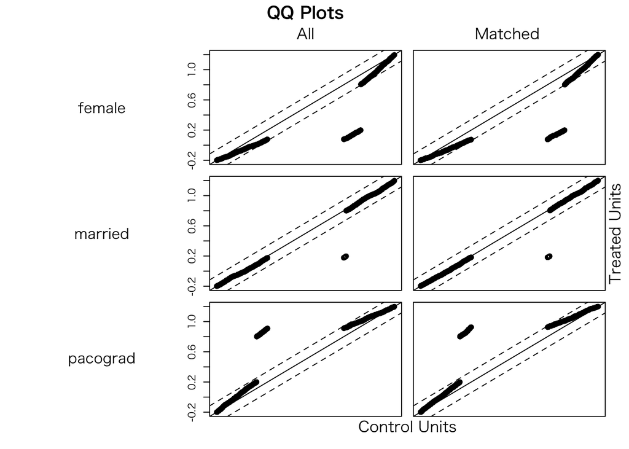

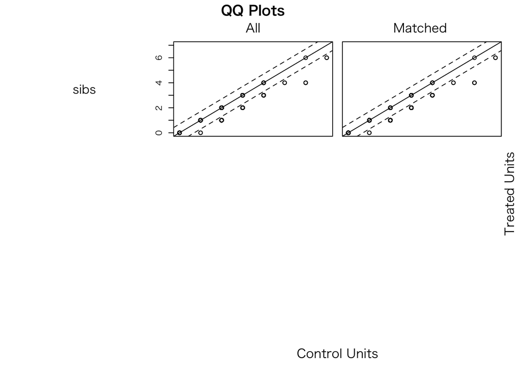

```r
plot(m_subclass, type = "QQ", interactive = FALSE)
```

続いて、傾向スコアの分布を確認してみよう。

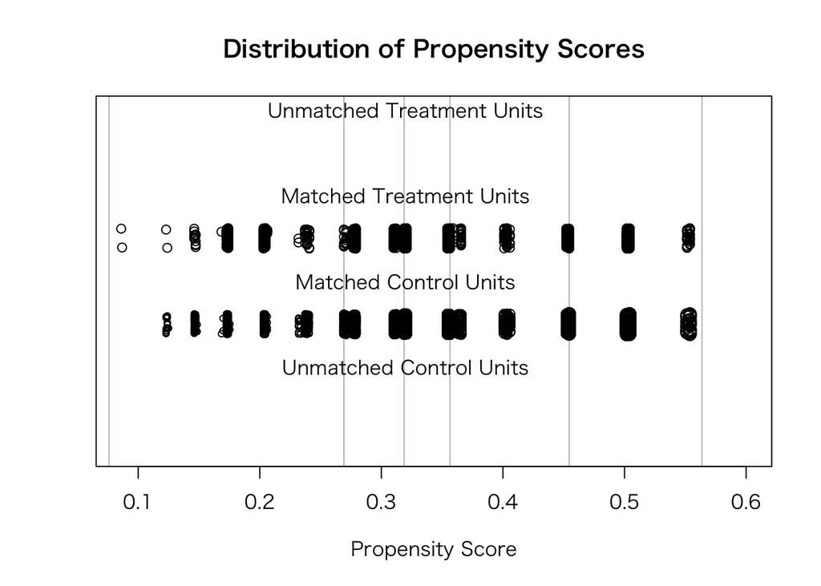

```r
plot(m_subclass, type = "jitter", interactive = FALSE)
```

同様に、傾向スコアの分布をヒストグラムでも確認してみよう。

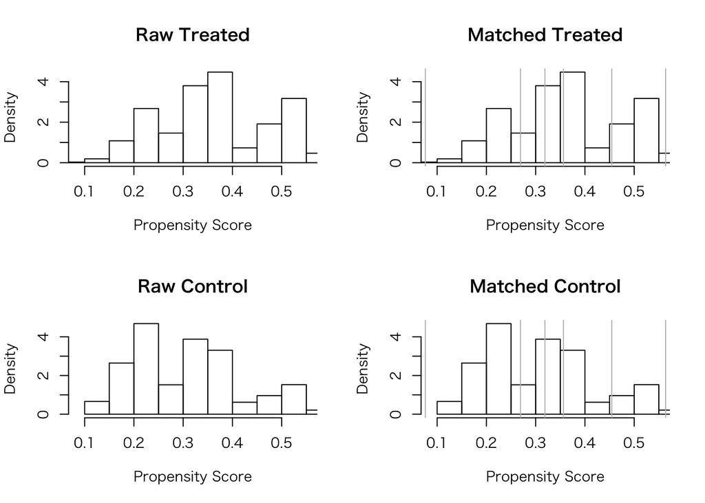

```r
plot(m_subclass, type = "hist", interactive = FALSE)
```

処置群と統制群で、分布の範囲は共有されているようである。

## 最近傍マッチング (Nearest Neighbor Matching)

最近傍マッチングをしてみよう。`method = nearest` を指定する。また、マハラノビス距離を使ってみる。

```r
m_nn <- matchit(cograd ~ female + married + pacograd + sibs,
                data = INC, method = "nearest", distance = "mahalanobis")
summary(m_nn)
```

```
##
## Call:
## matchit(formula = cograd ~ female + married + pacograd + sibs,
##     data = INC, method = "nearest", distance = "mahalanobis")
##
## Summary of balance for all data:
##          Means Treated Means Control SD Control Mean Diff eQQ Med eQQ Mean
## female          0.3728        0.5611     0.4963   -0.1883       0   0.1879
## married         0.4525        0.4762     0.4995   -0.0237       0   0.0234
## pacograd        0.4788        0.3370     0.4728    0.1418       0   0.1418
## sibs            1.3392        1.4712     0.8673   -0.1320       0   0.1308
##          eQQ Max
## female         1
## married        1
## pacograd       1
## sibs           2
##
##
## Summary of balance for matched data:
##          Means Treated Means Control SD Control Mean Diff eQQ Med eQQ Mean
## female          0.3728        0.3808     0.4858    -8e-03       0    8e-03
## married         0.4525        0.4518     0.4978     7e-04       0    7e-04
## pacograd        0.4788        0.4788     0.4997     0e+00       0    0e+00
## sibs            1.3392        1.3472     0.7554    -8e-03       0    8e-03
##          eQQ Max
## female         1
## married        1
## pacograd       0
## sibs           1
##
## Percent Balance Improvement:
##          Mean Diff. eQQ Med eQQ Mean eQQ Max
## female      95.7297       0  95.7198       0
## married     96.9163       0  96.8750       0
## pacograd   100.0000       0 100.0000     100
## sibs        93.9090       0  93.8547      50
##
## Sample sizes:
##           Control Treated
## All          3003    1368
## Matched      1368    1368
## Unmatched    1635       0
## Discarded       0       0
```

バランスはどうだろうか？標準化してみよう。

```r
(sum_m_nn <- summary(m_nn, standardize = TRUE))
```

```
##
## Call:
## matchit(formula = cograd ~ female + married + pacograd + sibs,
##     data = INC, method = "nearest", distance = "mahalanobis")
##
## Summary of balance for all data:
##          Means Treated Means Control SD Control Std. Mean Diff. eCDF Med
## female          0.3728        0.5611     0.4963         -0.3893   0.0941
## married         0.4525        0.4762     0.4995         -0.0476   0.0119
## pacograd        0.4788        0.3370     0.4728          0.2838   0.0709
## sibs            1.3392        1.4712     0.8673         -0.1763   0.0031
##          eCDF Mean eCDF Max
## female      0.0941   0.1883
## married     0.0119   0.0237
## pacograd    0.0709   0.1418
## sibs        0.0165   0.0762
##
##
## Summary of balance for matched data:
##          Means Treated Means Control SD Control Std. Mean Diff. eCDF Med
## female          0.3728        0.3808     0.4858         -0.0166   0.0040
## married         0.4525        0.4518     0.4978          0.0015   0.0004
## pacograd        0.4788        0.4788     0.4997          0.0000   0.0000
## sibs            1.3392        1.3472     0.7554         -0.0107   0.0015
##          eCDF Mean eCDF Max
## female      0.0040   0.0080
## married     0.0004   0.0007
## pacograd    0.0000   0.0000
## sibs        0.0013   0.0029
##
## Percent Balance Improvement:
##          Std. Mean Diff. eCDF Med eCDF Mean eCDF Max
## female           95.7297  95.7297   95.7297  95.7297
## married          96.9163  96.9163   96.9163  96.9163
## pacograd        100.0000 100.0000  100.0000 100.0000
## sibs             93.9090  53.3659   91.8787  96.1640
##
## Sample sizes:
##           Control Treated
## All          3003    1368
## Matched      1368    1368
## Unmatched    1635       0
## Discarded       0       0
```

それなりに良さそうに見える。

図でも確認しよう。

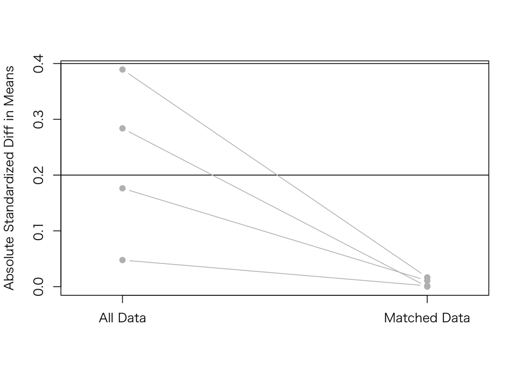

```r
plot(sum_m_nn, interactive = FALSE)
```

4つある共変量のすべてにおいてバランスが改善んしており、標準化バイアスの絶対値が0.1未満になっている。

次に、Q-Qプロットを確認してみよう。

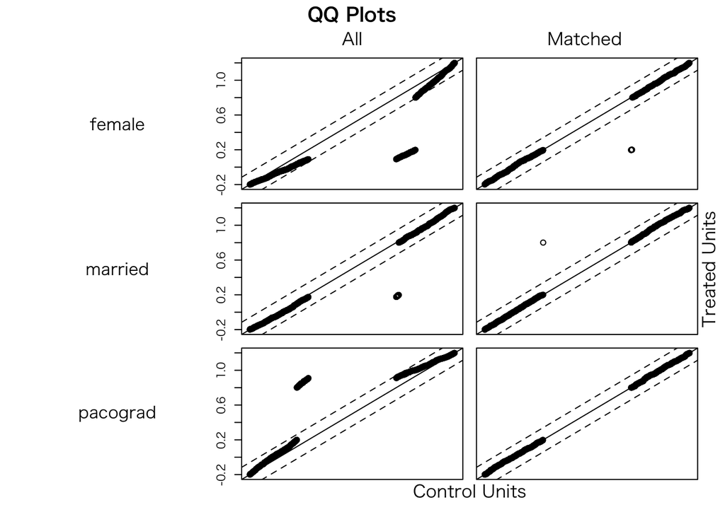

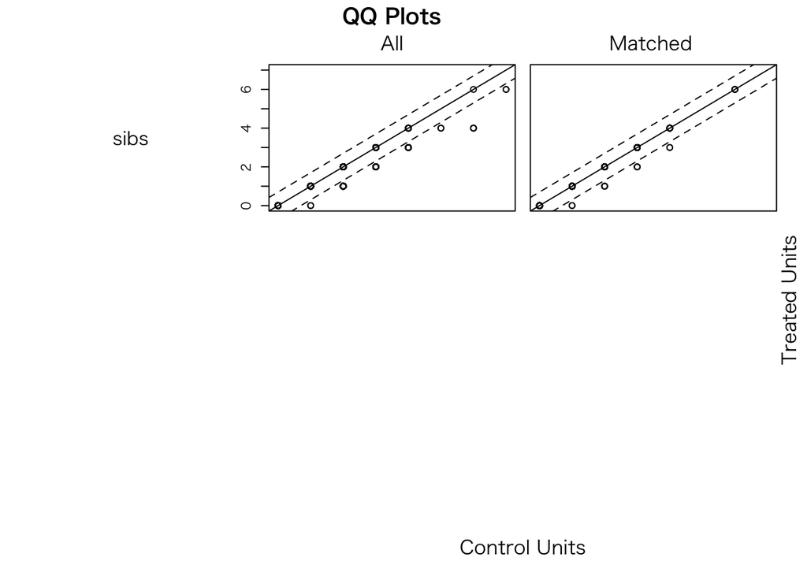

```r
plot(m_nn, type = "QQ", interactive = FALSE)
```

マッチング後のQ-Qプロットを見ると、ほぼ直線上に並んでいることがわかる。 バランスは良さそうだ。

# マッチング法：分析

マッチングできたら、マッチング後のデータを使って因果効果を推定する。 推定したいのは、大学卒業 (cograd) が対数所得 (lincome) に与える影響である。

## マッチング前のデータ

比較のため、まずマッチング前のデータを使って推定を行う。 共変量を無視して単回帰する。

```r
fit_0 <- lm(lincome ~ cograd, data = INC)
tidy(fit_0, detail = TRUE, digits = 3)
```

```
## # A tibble: 2 x 5
##   term        estimate std.error statistic   p.value
##   <chr>          <dbl>     <dbl>     <dbl>     <dbl>
## 1 (Intercept)    5.12     0.0147     348.  0.
## 2 cograd         0.603    0.0263      22.9 8.38e-110
```

大学卒業の係数の推定値は0.60、つまり、大学教育の収益率の推定値は60%であり、この効果は統計的に有意である。

共変量を使って重回帰する。

```r
fit_1 <- lm(lincome ~ cograd + female + married + pacograd + sibs,
            data = INC)
tidy(fit_1, detail = TRUE, digits = 3)
```

```
## # A tibble: 6 x 5
##   term        estimate std.error statistic  p.value
##   <chr>          <dbl>     <dbl>     <dbl>    <dbl>
## 1 (Intercept)   5.43      0.0310    175.   0.
## 2 cograd        0.548     0.0259     21.2  7.82e-95
## 3 female       -0.431     0.0237    -18.1  5.58e-71
## 4 married       0.0663    0.0235      2.82 4.84e- 3
## 5 pacograd     -0.192     0.0244     -7.89 3.73e-15
## 6 sibs         -0.0197    0.0141     -1.40 1.61e- 1
```

大学卒業の係数の推定値は0.55、つまり、大学教育の収益率の推定値は55%であり、この効果は統計的に有意である。共変量を統制しないと、効果が過大推定されることがわかる。

## マッチング後のデータ

上で試したマッチングのうち、最近傍マッチングのバランスが良さそうなので、その結果を使って分析しよう。`matchit()` の結果を使った分析を行うときは、`match.data()` でマッチング相手が見つかったデータを取り出した後、`Zelig::zelig()` を以下のように使う。

```r
data_m <- match.data(m_nn)
fit_m0 <- zelig(lincome ~ cograd, data = data_m, model = "ls")
```

```
## How to cite this model in Zelig:
##   R Core Team. 2007.
##   ls: Least Squares Regression for Continuous Dependent Variables
##   in Christine Choirat, Christopher Gandrud, James Honaker, Kosuke Imai, Gary King, and Olivia Lau,
##   "Zelig: Everyone's Statistical Software," http://zeligproject.org/
```

```r
summary(fit_m0)
```

```
## Model:
##
## Call:
## z5$zelig(formula = lincome ~ cograd, data = data_m)
##
## Residuals:
##     Min      1Q  Median      3Q     Max
## -3.8941 -0.2052  0.1313  0.4879  2.0211
##
## Coefficients:
##             Estimate Std. Error t value Pr(>|t|)
## (Intercept)  5.20516    0.02070  251.43   <2e-16
## cograd       0.52151    0.02928   17.81   <2e-16
##
## Residual standard error: 0.7657 on 2734 degrees of freedom
## Multiple R-squared:  0.104,  Adjusted R-squared:  0.1037
## F-statistic: 317.3 on 1 and 2734 DF,  p-value: < 2.2e-16
##
## Next step: Use 'setx' method
```

単回帰でも、マッチング前の重回帰とほぼ同じ推定量が得られる。

共変量を使って重回帰する。

```r
fit_m1 <- zelig(lincome ~ cograd + female + married + pacograd + sibs,
                data = data_m, model = "ls")
```

```
## How to cite this model in Zelig:
##   R Core Team. 2007.
##   ls: Least Squares Regression for Continuous Dependent Variables
##   in Christine Choirat, Christopher Gandrud, James Honaker, Kosuke Imai, Gary King, and Olivia Lau,
##   "Zelig: Everyone's Statistical Software," http://zeligproject.org/
```

```r
summary(fit_m1)
```

```
## Model:
##
## Call:
## z5$zelig(formula = lincome ~ cograd + female + married + pacograd +
##     sibs, data = data_m)
##
## Residuals:
##     Min      1Q  Median      3Q     Max
## -3.8876 -0.2835  0.1165  0.4431  2.1703
##
## Coefficients:
##             Estimate Std. Error t value Pr(>|t|)
## (Intercept)  5.35983    0.03808 140.748  < 2e-16
## cograd       0.51835    0.02793  18.557  < 2e-16
## female      -0.39105    0.02890 -13.529  < 2e-16
## married      0.14473    0.02818   5.135 3.02e-07
## pacograd    -0.18128    0.02805  -6.462 1.22e-10
## sibs         0.01164    0.01860   0.626    0.532
##
## Residual standard error: 0.7305 on 2730 degrees of freedom
## Multiple R-squared:  0.1857, Adjusted R-squared:  0.1842
## F-statistic: 124.5 on 5 and 2730 DF,  p-value: < 2.2e-16
##
## Next step: Use 'setx' method
```

正確マッチングしたデータを使うとどうなるか試してみよう。

```r
data_exact <- match.data(m_exact)
fit_m2 <- zelig(lincome ~ cograd, data = data_exact, model = "ls")
```

```
## How to cite this model in Zelig:
##   R Core Team. 2007.
##   ls: Least Squares Regression for Continuous Dependent Variables
##   in Christine Choirat, Christopher Gandrud, James Honaker, Kosuke Imai, Gary King, and Olivia Lau,
##   "Zelig: Everyone's Statistical Software," http://zeligproject.org/
```

```r
summary(fit_m2)
```

```
## Model:
##
## Call:
## z5$zelig(formula = lincome ~ cograd, data = data_exact)
##
## Residuals:
##     Min      1Q  Median      3Q     Max
## -3.8939 -0.2946  0.1754  0.4881  2.1033
##
## Coefficients:
##             Estimate Std. Error t value Pr(>|t|)
## (Intercept)  5.12295    0.01477  346.85   <2e-16
## cograd       0.60352    0.02634   22.91   <2e-16
##
## Residual standard error: 0.8062 on 4343 degrees of freedom
## Multiple R-squared:  0.1078, Adjusted R-squared:  0.1076
## F-statistic: 524.9 on 1 and 4343 DF,  p-value: < 2.2e-16
##
## Next step: Use 'setx' method
```

授業の内容に戻る